# Introduction to Julia

Julia is a young, free, open-source and promising general-purpose language, designed and developed by Jeff Bezason, Alan Edelman, Viral B. Shah and Stefan Karpinski in MIT. For years, the requirements of a language of having, on one hand, a clear, simple syntax, easy readability, and good abstraction capabilities, while in the other hand being designed for technical, high-performance and resource-intensive computations, have been thought as mutually exclusive. This led applied scientists to face the task of not only learning two different languages –one high-level, the other low-level-, but also learning how to communicate between them, which is far from trivial in a lot of cases. This is called the *two language problem*, and it costs programmers and scientists valuable time and effort which may be better to invest in solving the underlying *true* problems, which required of computations to be tackled in the first place. This is where Julia makes its appeareance, intending to bridge the gap present in the two language problem, designed from its roots for being fast and easy to understand, even for people who are not programmers or computer scientists. Julia is dynamically typed and is great for interactive use. It also uses *multiple dispatch* as a core design concept, which adds to the composability of the language. In conventional, single-dispatched, object-oriented programming languages, when invoking a method, one of the arguments is treated specially and it determines which of all the methods with that same name is going to be appled. Multiple dispatch is a generalization of this for all the arguments of the function called, so the method applied is going to be the one that matches exactly the the number of type of the function call.

Let's get our hands dirty with some Julia code in an example regarding the fibonacci sequence to see what it looks like:

12.5 μs

```
fibonacci (generic function with 1 method)
```

```
xxxxxxxxxx
```

15

1

```
begin
```

2

```
    n1 = 0
```

3

```
    n2 = 1
```

4

```
    m = 10
```

5

6

```
    function fibonacci(n1, n2, m)
```

7

```
        fib = Array{Int64,1}(undef, m)
```

8

```
        fib[1] = n1
```

9

```
        fib[2] = n2
```

10

```
        for i in 3:m
```

11

```
            fib[i] = fib[i-1] + fib[i-2]
```

12

```
        end
```

13

```
        return fib
```

14

```
    end
```

15

```
end
```

32.4 μs

As you can see, writing Julia code is pretty straight-forward. First of all, we made some variable assignaments, variables , and were asigned with values 0, 1 and 10. Then, we defined a function for the fibonacci calculation. Function blocks start with the *function* statement, followed by the name of the function and the arguments within brackets. This arguments will be the two first numbers of the sequence and the total length of the sequence. Inside the function definition, first we initialize an array of integers of one dimention and length . This way of initializing an array is not strictly necessary, but is definitely a good practice for optimizing code performance in Julia. Don't worry too much about that right now, though. We then proceed to assign the two first elements of the sequence and calculate the rest with a for loop. The syntax `3:m` just means all the numbers from 3 to `m`, with a step of 1. We could have set `3:2:m` if we wanted a step of 2 between each iteration. Finally, an *end* statement is necessary at the end of the for loop, as well as for ending the function definition. Evaluating our function in the variables , and already defined, gives us

17 μs

Int641

```
0
```

2

```
1
```

3

```
1
```

4

```
2
```

5

```
3
```

6

```
5
```

7

```
8
```

8

```
13
```

9

```
21
```

10

```
34
```

```
xxxxxxxxxx
```

1

1

```
fibonacci(n1, n2, m)
```

11.9 ms

Let's see some other nice Julia functionalities. Suppose you wanted to add the number 2 to every element of an array. You may be tempted to try this code, but you are going to get an error message

7 μs

MethodError: no method matching +(::Array{Int64,1}, ::Int64)

For element-wise addition, use broadcasting with dot syntax: array .+ scalar

Closest candidates are:

+(::Any, ::Any, !Matched::Any, !Matched::Any...) at operators.jl:538

+(!Matched::Missing, ::Number) at missing.jl:115

+(!Matched::BigFloat, ::Union{Int16, Int32, Int64, Int8}) at mpfr.jl:378

...

1. **top-level scope**@*Local: 3*

```
xxxxxxxxxx
```

4

1

```
begin
```

2

```
    arr = [1, 2, 2, 3, 6]
```

3

```
    arr + 2
```

4

```
end
```

---

If you watch closely, the message makes a good suggestion: the *broadcast operator*. When you have an operator applied to some iterable object, adding a dot in front of that operator broadcasts the operation for every element of the object. This is what the dot syntax mentioned in the error message refers to. Let's see it in action:

8.8 μs

Int641

```
3
```

2

```
4
```

3

```
4
```

4

```
5
```

5

```
8
```

```
xxxxxxxxxx
```

1

1

```
arr .+ 2
```

54.9 ms

This is also useful when doing some vector operations. In Julia, one-dimensional arrays initialized by separating its elements with commas can be thought as column vectors. For example, we can define two column vectors

3.2 μsvec1

Int641

```
1
```

2

```
0
```

3

```
1
```

4.2 μsvec2

Int641

```
2
```

2

```
1
```

3

```
1
```

4.1 μs

If we would try to do something like `vec1 * vec2`, this is an ambiguous operation, because Julia doesn't know if we mean a dot product,cross product or maybe something else. But if we add the dot syntax operator, `vec1 .* vec2`, Julia makes a element-wise multiplication between the elements of the two vectors:

3.4 μs

Int641

```
2
```

2

```
0
```

3

```
1
```

```
xxxxxxxxxx
```

1

1

```
vec1 .* vec2
```

67.4 ms

If we would have used the broadcast operator between a column vector and a *row* vector instead, the broadcast is done for every row of the first vector and every column of the second vector, returning a matrix. A row vector can be initialized using whitespaces to separate each element, like so

7 μsvec3

```
1×3 Array{Int64,2}:
 3  1  4
```

```
xxxxxxxxxx
```

1

1

```
vec3 = [3 1 4]
```

30 ms

So if we do, por example `vec1 .* vec3`, we get

9.4 μs

```
3×3 Array{Int64,2}:
 3  1  4
 0  0  0
 3  1  4
```

```
xxxxxxxxxx
```

1

1

```
 vec1 .* vec3
```

97.7 ms

We will be using the broadcast dot syntax throughout the book, and it is used extensively in the Julia community due to its usefulness. Broadcasting can be used on functions too. Say you have a function that tells you if a number is positive

5 μs

```
isPositive (generic function with 1 method)
```

```
xxxxxxxxxx
```

9

1

```
begin
```

2

```
    function isPositive(x)
```

3

```
        if x >= 0
```

4

```
            return true
```

5

```
        elseif x < 0
```

6

```
            return false
```

7

```
        end
```

8

```
    end
```

9

```
end
```

20.3 μs

```
true
```

```
xxxxxxxxxx
```

1

1

```
isPositive(3)
```

3.4 ms

Using the dot syntax, this function can be applied over an entire array

3 μs

BitArray{1}: 1

```
true
```

2

```
true
```

3

```
true
```

4

```
false
```

5

```
true
```

6

```
false
```

```
xxxxxxxxxx
```

1

1

```
isPositive.([2, 3, 5, -2, 1, -4])
```

148 ms

Julia's ecosystem is composed by a variety of libraries which focus on techical domains such as DataScience (DataFrames.jl, CSV.jl), Machine Learning (MLJ.jl, Flux.jl, Turing.jl) and Scientific Computing (DifferentialEquations.jl), as well as more general purpose programming (HTTP.jl, Dash.jl). We will consider one of the libraries that will be accompanying us throughout the book for making visualizations, and it is the standard package for plotting. It is called Plots.jl. Let's import the library first,

105 μs

```
xxxxxxxxxx
```

1

1

```
using Plots
```

10.7 s

Let's make a plot of the 10 first numbers in the fibonacci sequence. For this, we can make use of the `scatter()` function:

6.4 μs

[figure not shown]

```
xxxxxxxxxx
```

4

1

```
begin
```

2

```
    sequence = fibonacci(n1, n2, m)
```

3

```
    scatter(sequence, xlabel="n", ylabel="Fibonacci(n)", color="purple", label=false, size=(450, 300))
```

4

```
end
```

1.5 ms

The only really important argument of the scatter function in the example above is *sequence*, the first one, which tells the function what is the data we want to plot. The other arguments are just details to make the visualization prettier. Here we have used the *scatter* function because we want a discrete plot for our sequence. In case we wanted a continuous one, we could have used *plot()*. Let's see this applied to our fibonacci sequence:

9.1 μs

[figure not shown]

```
xxxxxxxxxx
```

1

1

```
plot(sequence, xlabel="x", ylabel="Fibonacci", linewidth=3, label=false, color="green", size=(450, 300))
```

56.8 ms

[figure not shown]

```
xxxxxxxxxx
```

4

1

```
begin
```

2

```
    plot(sequence, xlabel="x", ylabel="Fibonacci", linewidth=3, label=false, color="green", size=(450, 300))
```

3

```
    scatter!(sequence, label=false, color="purple", size=(450, 300))
```

4

```
end
```

711 ms

You may have noticed que exclamation mark (or 'bang', as it is called in the Julia community) next to the scatter function. In Julia, functions with a bang are functions that modify variables *in-place*. In the example above, a plot is created when we call the plot() function. What the scatter!() call then does, is to modify the global state of the plot in-place. If not done this way, both plots wouldn't be sketched together.

4.5 μs

As mentioned, Julia is specially suited for areas related with scientific and high-performance computations. Between these, we have *Probabilistic Programming*, and more generally *Bayesian Statistics*. These two fields are strongly related to each other and are the main focus of the book. First, we will need to get some intuitive idea about what Bayesian Statistics is, so let's go for it

330 μs

# Introduction to Bayes

5.5 μs

Uncertainty is our brains' common currency. It naturally knows, for example, how plausible an event is. We know that some events, as a big volcano eruption are rare, and some others like rain are more common. This plausibility and our understanding of the world in general depends heavily on the data we measure, in other words, our past observations, and the model we have about the world. For example, we know that in the desert is less likely to rain that in a Caribbean town. We infer that because we have an internal model for such events. As we grew up, those models changed with time, we have updated them as we collected new data, had new experiences. It that sense, we are all the time interacting with new stimuli, thinking how to react and, based on past experience, what we need to do next in order to have the outcome we want.

It would be nice and useful to think about problems in that way, firstly because we can relate very much with this approach of solving problems, and also because it allows us to make models, using previous information or intuition (an arguable word for experience) and working with uncertainty in such a natural way, arising as an intrinsic property of the data and how we measure it.

A Bayesian way of thinking aligns very good with this train of thought. These groups of techniques are not new, in fact they even were the first conceptions of what we call now *probability and statistics*, formulated mathematically speaking by Thomas Bayes and published posthumously in 1763.

But before explicitly digging into a Bayesian framework and explaining how to express those ideas in a more mathematical way, we are going to introduce some concepts first that will help us to a better and deep understanding.

13.4 μs

## Distributions and sampling

3 μs

### Distributions and histograms

We have talked about events, but how are they related to probability? A probability distribution is a function that tells us how likely is an event to occur and it can take values between 0 and 1. Events with a probability near to 0 are less likely to occur, on the contrary, events near to 1 are more likely to happen. Probability distributions can have very different and interesting properties and shapes, they can express the probability of continuous events, such as height or amount of rainfall, but also they can map discrete events, such as heads in *N* flips of a coin, to its probability.

10.7 μs

To illustrate some of these concepts, we are going to use [monthly rainfall data](https://data.buenosaires.gob.ar/dataset/registro-precipitaciones-ciudad) from the city of Buenos Aires, Argentina, since 1991. The **histogram** of the data is shown below. An histogram is a plot that tells us the relative frequency of events, it's just a representation for the action of counting event.

68.1 μs

```
xxxxxxxxxx
```

1

1

```
using CSV
```

246 μs

```
x
```

1

```
begin
```

2

```
    data_dir = "./data/"
```

3

```
    rain_data = CSV.read(data_dir*"historico_precipitaciones.csv")
```

4

```
end;
```

1.1 ms

We can see the first rows of our data, having columns for the year, the month, the rain precipitation (in millimeters) and the number of days with rain that month.

7 μs

8 rows × 4 columns

|  | año Int64 | mes String | mm Float64 | días Int64 |
| --- | --- | --- | --- | --- |
| 1 | 1991 | Enero | 190.0 | 7 |
| 2 | 1991 | Febrero | 30.5 | 6 |
| 3 | 1991 | Marzo | 55.0 | 8 |
| 4 | 1991 | Abril | 125.6 | 12 |
| 5 | 1991 | Mayo | 68.4 | 7 |
| 6 | 1991 | Junio | 119.7 | 10 |
| 7 | 1991 | Julio | 89.3 | 8 |
| 8 | 1991 | Agosto | 66.4 | 7 |

23.5 μs

Now plotting the histogram for the column of rainfall in mm we have the figure shown below:

3.1 μs

[figure not shown]

2.3 ms

But we said the probability is a number between 0 and 1, so we now normalize the plot to have the values constrained. Normalizing a plot is just adjusting the scale of variables without changing the shape of the plot, as we can see in the normalized plot shown below. You can notice that the values of frequency are very low now, and the reason it that we have to fulfill another important property: the area of the plot must be 1. But why? As probability tell us how plausible is an event, if we take into account all the events, we expect that the probability of all those events reach a maximum value, and that value is set up to 1 by convention.. In that way we can compare plausibilities across different events, therefore when we say that some event has a probability of 60% to occur, for any event it means the same, no matter if we are talking about the probability of raining or the probability of being hit by a car. So, we normalize the histogram obtaining:

9.2 μs

[figure not shown]

2.2 ms

We can say a lot about this plot, then we are going now to analyse it. First, it is worth noting that a rainfall amount less than 0 mm is not possible, that's why we don't have any event in this region. On the other hand, we see that a monthly rainfall higher than 300 mm is a rare event, and a rainfall higher than 400 mm is even less likely to happen.

But why am I inferring how likely is an event to happen in the future with data from the past?

I'm making some assumptions that are often implied working with histograms and measured data: the first assumption is that the data is representative for the variable in consideration, meaning that the data of rainfall was measured well, that it isn't measured just during winter for example, when we know rainfall is most common. The other big assumption is that things in the future will not change much from things in the past, so if we do the measure again for some time in the near future, the shape of the histogram is going to be more or less the same.

4.5 μs

### Sampling

Let's introduce now an important concept: sampling.

To clarify the concept, we will run a mental experiment: suppose we want to guess how will look like the histogram of the data for the rainfall in Buenos Aires if we collect measurements for the next 5 years.

Do really we need to wait to have a 'sample' of the experiment?

The answer is no. We already know that the shape of the histogram will be similar to one we have with the values measured before. All we need to do is to 'create' a series of plausible values. There are a couple of simple methods to do that. For example, we could draw a random coordinate, like in the plot shown below, with x values between 0 and 440 and y values between 0 and 0.007, if the point lays in the blue region (any bar from the histogram) we take the point as a plausible sample, but if the point falls outside any blue bar, we discard the point. In the plot 2 points are draw, a green point and red point, taking the first as a plausible point and discarding the second one.

28.9 μs

[figure not shown]

43.5 ms

We encourage the reader to apply this method for multiple points and plot the histogram of the plausible points. It does look similar to the one we have before, right?.

But instead of the method we have described, we are going to use some built in methods.

3.8 μs

In the problems we'll see in the book, we will often need to work with distributions that depends on parameters, being those parameters also distributions, so the simpler methods for sampling are not so efficient. We are going to use fancier methods for sampling points that are, computationally speaking, less expensive, addressing very well some other complications that appear when working with high dimensional variables.

3.3 μs

So we are going to use a sampler function from the Julia's StatsBase library, and to apply it to our rainfall example, we only need to pass:

1. The rainfall values we have measured in the past.
2. How many new plausible samples we want the function to 'create'.

We plotted below the histogram of the sampled values obtained, with the code used. Seeing the histogram, the points seem plausible, right? Who could guess they were sampled values and not actually measured data?.

5 μs

[figure not shown]

3.2 ms

Now that we have the concept of sampling, we could point out why this will help us. At the beginning we said that in a Bayesian framework, we have a model of the problem we want to address and maybe some data we want to use. So, we want somehow to use the data to update our model, also maybe to fit a parameter we don't know its value or simply to guess what are the more plausible values for the parameters of the model we propose. In order to answer those very important questions we need sampling, infering how plausible are the parameters' values with the data we have, again by sampling.

7.1 μs

### Turing.jl and Soss.jl for Probabilistic Programming

We will now introduce some important libraries used in the book. Libraries in general with the purpose of bringing together traditional general purpose programming and probabilistic modeling are called **probabilistic programming languages** or PPLs. Here we are going to use **Turing.jl** and **Soss.jl**, two PPLs written in Julia. In the next example is shown how to use them, and some peculiar features of each one.

19.9 μs

##### Example: Flipping a coin

11.7 μs

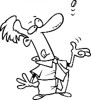

19.7 ms

We are going now to explain a well known example: flipping a coin, but from a Bayesian perspective ;).

So the problem goes like this:

Suppose we flip a coin N times, and we ask our self some questions like :

- Is having heads as likely as having tails?
- Is our coin biased, preferring one output over the other?

To answer these questions we are going to build a simple model.

First at all: Do we have *prior* information about the problem? Well, yes, we do. We know that the value of *p* (since is the probability of having heads) lays between 0 and 1.

Do we know anything more?

Let's skip that question for the moment and suppose we don't know anything more about *p*. Not knowing anything is also some kind of information for my model.

How?

Because we can assign equal probability for each value of *p* between 0 and 1, and 0 probability for the remaing values. So, translating that into a probability distribution, it means that we are going to use a *Uniform* prior distribution for *p* and this uniform distribution between 0 and 1.

Why 'prior'?

We will explain that in just a moment, but you can gess why.

39.3 μs

The histogram of *p* build with sampled values from out prior uniform distribution is shown below:

8.2 μs

[figure not shown]

23.6 ms

We see that the plot is almost a straight line, the *almost* comes from the fact that we are sampling an uniform distribution.

4.6 μs

Continuing with the problem, how do we model the outcomes of flipping a coin?

Well, if we search for some similar type of experiment we find that all processes in which we have 2 possible outcomes, heads or tails in this case, and a probability of success *p* (probability of heads) are called *Bernoulli* trials. Therefore we are going to model the outcome with a bernoulli distribution, which has *p* as a parameter.

But how do we update out bernoulli model with the outcomes we had flipping the coin?

Bayes' theorem comes in to help us now.

10.3 μs

#### Bayes theorem

3.1 μs

Now we are going to explain a bit more about a theorem used in all Bayesian frameworks, that is the **Bayes' theorem**.

How does this theorem relate to our Bayesian perspective of solving problems?

Well, actually by analysing the equation we can summarize a lot of what we have talked about updating models with data. If we consider P(A) to be our *prior* knowledge about the problem, and B the data we have, then P(B|A) is the plausibility of the data given the model we have proposed. On the other hand, P(A|B) is the plausibility of the model given the data, and that is what we want to know!!. The remaining term P(B) is just a normalization to preserve the properties of a probability distribution: that summing the probability of all event adds up to 1, so don't worry about it.

15.8 μs

9.7 μs

The model *coinflip* is shown below. We have use here the Turing library. To define a model we use the macro *@model*. Variables that follow a distribution are defined with a ~ simbol, and deterministic variables are defined with the = simbol.

16.9 μs

```
xxxxxxxxxx
```

1

1

```
using Turing
```

15.9 s

```
coinflip (generic function with 1 method)
```

```
xxxxxxxxxx
```

14

1

```
begin
```

2

```
@model coinflip(y) = begin
```

3

4

```
    # Our prior belief about the probability of heads in a coin.
```

5

```
    p ~ Uniform(0, 1)
```

6

7

```
    # The number of observations.
```

8

```
    N = length(y)
```

9

```
    for n in 1:N
```

10

```
        # Heads or tails of a coin are drawn from a Bernoulli distribution.
```

11

```
        y[n] ~ Bernoulli(p)
```

12

```
    end
```

13

```
end;
```

14

```
end
```

70.2 μs

The model *coinflip* receives the *N* outcomes of our flips, a vector of lenght *N* with 0 or 1 values, 0 values indicating fails or an outcome of tails and 1 indicating sucesses or heads. The idea is that with each new value of outcome, the model will be updating its believes about the parameter *p* and this is what the for loop is doing: we are saying that each outcome comes from a Bernoulli distribution with a parameter *p*, a success probability, shared for all the outcomes.

Suppose we have run the experiment 10 times and had the outcomes:

11.5 μsoutcome

Int641

```
0
```

2

```
1
```

3

```
1
```

4

```
0
```

5

```
1
```

6

```
0
```

7

```
0
```

8

```
1
```

9

```
1
```

10

```
1
```

```
xxxxxxxxxx
```

1

1

```
outcome = [0, 1, 1, 0, 1, 0, 0, 1, 1, 1]
```

3.5 μs

So, we had 6 heads and 4 tails.

2.8 μs

Now, we are going to see now how the model, for our unknown parameter *p*, is updated. We will start by giving only just one input value to the model, adding one input at a time. Finally, we will give the model all outcomes values as input.

4.6 μs

```
xxxxxxxxxx
```

9

1

```
begin
```

2

```
# Settings of the Hamiltonian Monte Carlo (HMC) sampler.
```

3

```
iterations = 1000
```

4

```
ϵ = 0.05
```

5

```
τ = 10
```

6

7

```
# Start sampling.
```

8

```
chain = sample(coinflip(outcome[1]), HMC(ϵ, τ), iterations, progress=false);
```

9

```
end;
```

2.5 s

So now we plot below the posterior distribution of p after our model updated, seeing just the first outcome, a 0 value or a tail.

How this single outcome have affected our beliefs about p?

We can see in the plot below, showing the posterior or updated distribution of *p*, that the values of *p* near to 0 have more probability than before, recalling that all values had the same probability, which makes sense if all our model has seen is a faliure, so it lowers the probability for values of p that suggest high rates of success.

6.4 μs

[figure not shown]

159 ms

Let's continue now including the remainig outcomes and see how the model is updated.

4.3 μs

We have plotted below the posterior probability of *p* adding outcomes to our model updating its beliefs.

6.4 μs

```
xxxxxxxxxx
```

8

1

```
begin
```

2

```
    samples = []
```

3

```
    for i in 2:10
```

4

```
        global chain_
```

5

```
        chain_ = sample(coinflip(outcome[1:i]), HMC(ϵ, τ), iterations, progress=false)
```

6

```
        push!(samples, chain_[:p])
```

7

```
    end
```

8

```
end;
```

1.7 s

[figure not shown]

79.6 ms

We see that with each new value the model believes more and more that the value of *p* is far from 0 or 1, because if it was the case we would have only heads or tails. The model prefers values the of *p* in between, being the values near 0.5 more plausible with each update.

5.2 μs

What if we wanted to include more previous knowledge about the success rate *p*?

Let's say we know that the value of *p* is near 0.5 but we are not so sure about the exact value, and we want the model to find the plausibility for the values of *p*. Then including this knowledge, our prior distribution for *p* will have higher probability for values near 0.5, and low probability for values near 0 or 1. Seaching again in our repertoire of distributions, one that fulfill our wishes is a Beta distribution with parameters α=2 and β=2. It is ploted below.

8.2 μs

[figure not shown]

65.7 ms

Now we define again our model just changing the distribution for *p*, as shown:

4.5 μs

```
coinflip_beta_prior (generic function with 1 method)
```

```
x
```

1

```
begin
```

2

```
    @model coinflip_beta_prior(y) = begin
```

3

4

```
        # Our prior belief about the probability of heads in a coin.
```

5

```
        p ~ Beta(2, 2)
```

6

7

```
        # The number of observations.
```

8

```
        N = length(y)
```

9

```
        for n in 1:N
```

10

```
            # Heads or tails of a coin are drawn from a Bernoulli distribution.
```

11

```
            y[n] ~ Bernoulli(p)
```

12

```
        end
```

13

```
    end;
```

14

```
end
```

139 μs

Running the new model and plotting the posterior distributions, again adding one observation at a time, we see that with less examples we have a better approximations for the value of p.

2.9 μs

3.7 s

[figure not shown]

54.6 ms

To illustrate the affirmation made before, we can compare for example the posterior distributions obtained only with the first 4 outcomes for both models, the one with a uniform prior and the other with the beta prior. The plots are shown below. We see that some values near 0 and 1 have still high probability for the model with a uniform prior for p, while in the model with a beta prior the values near 0.5 have higher probability. That's because if we tell the model from the beginning that *p* near 0 and 1 have less probability, it catchs up faster that probabilities near 0.5 are higher.

4.9 μs

[figure not shown]

647 μs

So in this case, incorporating our beliefs in the prior distribution we saw the model reached faster the more plausible values for *p*, needing less outcomes to reach a very similar posterior distribution. When we used an uniform prior, we were conservative, meaning that we said we didn't know anything about *p* so we assign equal probability for all values. Sometimes these kind of distribution (uniform distributions), called a non-informative prior, can be maybe too conservative, being in some cases not helpful at all. They even can slow the convergence of the model to the more plausible values for our posterior, as shown.

5.5 μs